# **Maize growth and yield responses to conservative tillage system and starter fertilization strategies**

Michela Battisti, Luca Capo, Laura Zavattaro, Massimo Blandino

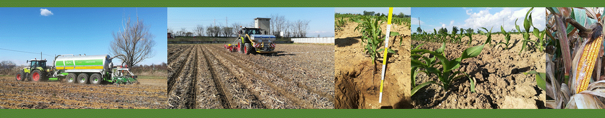

## **What you can find here?**

- Tillage techniques diffusion
- Strip-tillage and digestate injection videos
- Influence of tillage technique and starter fertilisation on maize grain yield components

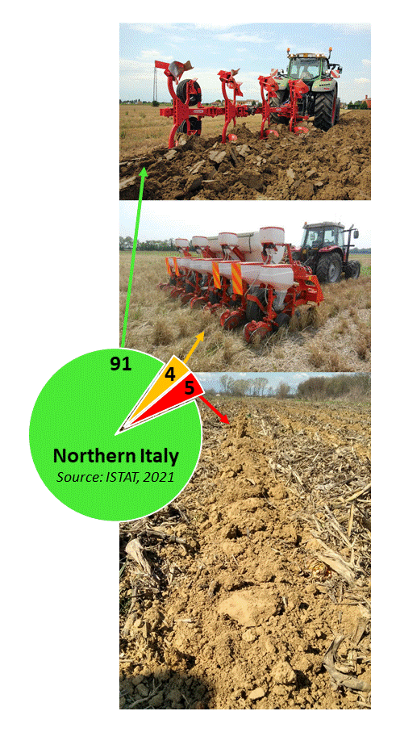

Conventional ploughing as primary tillage followed by secondary operations is widely practiced to provide a suitable seedbed for crops in the USA, Europe, North Africa and Asia (Fischer and Hobbs, 2019). However, over the last decade the adoption of conservation agriculture (i.e., no or minimum mechanical soil disturbance, surface retention of crop residues and rotation of crops) has increased up to 12.5% of the global cropped area (Kassam et al., 2019).

In Northern Italy, according to the Census of Agriculture (ISTAT, 2021), conventional tillage is adopted on 91.3% of the total arable surface, while only 4.1% of the surface is managed with no-till and 4.6% with reduced tillage techniques.

Conservation and no-tillage techniques still determine several concerns on as they might negatively affect the soil environment with cooler temperatures, higher moisture contents and greater penetration resistance. All these conditions may negatively influence the critical phase of crop establishment, and result in a delay in emergence and slower early growth (Licht and Al-Kaisi, 2005). The strip-tillage technique could help reduce the adverse effect of no-till, thus maintaining most of its positive characteristics. With this technique, a narrow strip is tilled and prepared as seedbed with a single passage that also includes the displacement of previous crop residues and the incorporation of fertilisers.

[figure not shown]

[figure not shown]

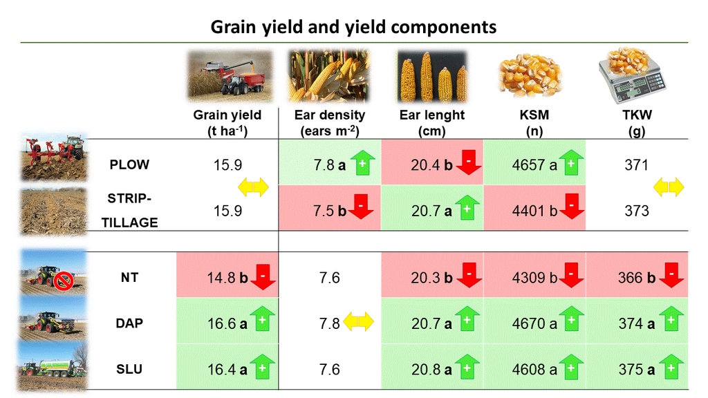